# Lab Quiz 1

Evan O’Toole

Jan 31, 2025

# Likelihood methods for the Poisson distribution

- Put your name in the author section above.
- Write R code in the R chunks provided to answer the questions posed.
- Execute each chunk of code to ensure that your code works properly.
- Sometimes one of your chucks of code will not compile properly, but you must hand your document in. In that case, ‘Comment’ out the R code that is not working properly using # as the first character in your lines of code.
- Save the Rmd file.
- Knit the Rmd file to pdf.
- Upload the pdf file to the **Lab Quiz 1 Assignment Activity** in the Lab section of Brightspace. * If your file will not knit to pdf, then knit to Word and save the Word document as a pdf.

## 1. First generate 1 observation from the Poisson(lambda=5) distribution and print the value. [2 marks]

(Hint: See help for the R function called *rpois*.)

```r
set.seed(12345)   #use this seed!
n <- 1
rpois(n,5)
```

```
## [1] 6
```

## 2. Compute the Log-likelihood for a vector sequence of lambda values from 2 to 7 in steps of .05. [3 marks]

(Hint: See help for the R function called *dpois*.)

```r
obs <- rpois(n,5)
lambda <- seq(2,7,0.05)
dval <- dpois(obs, lambda, log=TRUE)
```

## 3. Plot the Log-Likelihood function values from your answer in 2 versus lambda. Axes must be labelled and the plot must have a title. [5 marks]

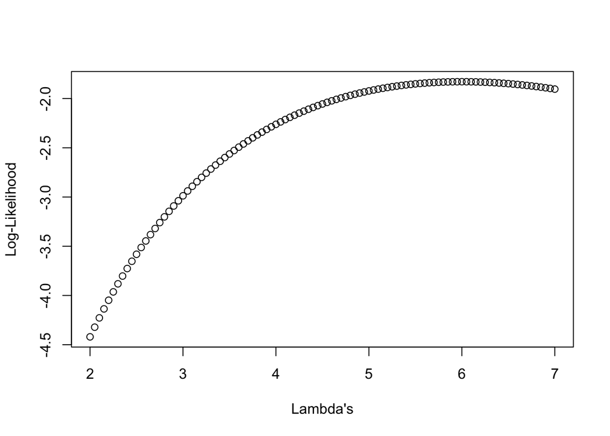

```r
obs <- rpois(n,5)
dval <- dpois(obs, seq(2,7,0.05), log=TRUE)
lambda <- seq(2,7,0.05)
plot(dval~lambda, ylab = "Log-Likelihood", xlab = "Lambda's", type = 'p')
```